# A Functional Neuroimaging Investigation of Moral Foundations Theory

## Design

Participants (n = 27; 14 males, 13 females; mean age (SD) = 24.65 (4.21) years) incidentally encoded 120 vignettes, 15 from each of the different foundations postulated by Moral Foundations Theory (Haidt and Joseph, 2007; Graham et al., 2012) and 15 depicting transgressions of amoral social norms. This took place inside the scanner, where they had 6 seconds to make a moral judgment about each (1-4: not morally wrong-extremely morally wrong).

The memory test took place outside of the scanner. Participants were cued with each vignette presented during study + 8 lures per foundation (including social norms, only 7 lures were presented for Purity). Each vignette had up to 4 words removed, and participants were asked to select which word or words completed the vignette as well as their confidence in their response (not confident-extremely confident; 1-4).

After the memory test, participants completed a host of questionnaires: the Moral Foundations Questionnaire, the Social and Economic Conservatism Scale, the Disgust Scale-Revised, the Interpersonal Reactivity Index, and ranked their emotional responses to the vignettes (6 different emotions/vignette).

##### In all following plots, binding foundations are shown in red and individualizing foundations are shown in blue (to hint at political ideology). All PLS analyses were performed with 1000 permutations and 250 rounds of bootstrapping.

$~$

#### Moral judgment normality check

To confirm that our sample had normal responses to the Moral Foundations Vignettes. Note that that paper used a five-point scale (0-4), whereas we used a four point scale.

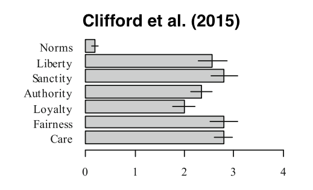

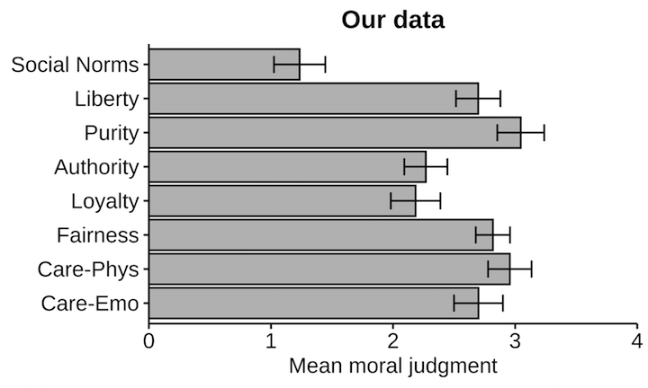

### Analyzing moral judgments

```r
modelMoral <- lmer(moral_decision ~ category + (1 | subID) + (1|vigfile), data = data_old, control=lmerControl(optCtrl = list(maxeval=5000)))
```

|  | moral_decision |  |  |
| --- | --- | --- | --- |
| Predictors | Estimates | CI | p |
| (Intercept) | 1.21 | 1.00 – 1.41 | **<0.001** |
| category [Authority] | 1.05 | 0.81 – 1.29 | **<0.001** |
| category [Loyalty] | 0.95 | 0.71 – 1.20 | **<0.001** |
| category [Purity] | 1.87 | 1.62 – 2.11 | **<0.001** |
| category [Care-Emo] | 1.49 | 1.25 – 1.74 | **<0.001** |
| category [Care-Phys] | 1.76 | 1.51 – 2.00 | **<0.001** |
| category [Fairness] | 1.62 | 1.38 – 1.86 | **<0.001** |
| category [Liberty] | 1.50 | 1.26 – 1.74 | **<0.001** |
| Random Effects |  |  |  |
| σ<sup>2</sup> | 0.55 |  |  |
| τ<sub>00</sub> <sub>vigfile</sub> | 0.09 |  |  |
| τ<sub>00</sub> <sub>subID</sub> | 0.08 |  |  |
| N <sub>subID</sub> | 27 |  |  |
| N <sub>vigfile</sub> | 120 |  |  |
| Observations | 3154 |  |  |

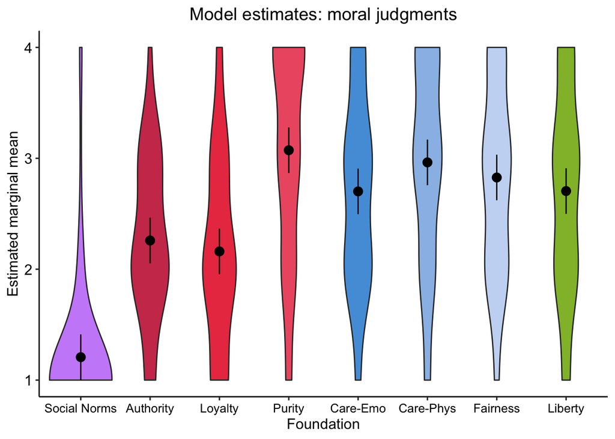

| contrast | estimate | SE | df | t.ratio | p.value |
| --- | --- | --- | --- | --- | --- |
| LibertyVsSocial | 1.4981577 | 0.1235891 | 111.8724 | 12.122083 | 0.000000 |
| BindingVsSocial | 1.2906747 | 0.1008918 | 111.7942 | 12.792665 | 0.000000 |
| IndividualizingVsSocial | 1.6239270 | 0.1008551 | 111.6329 | 16.101579 | 0.000000 |
| LibertyVsBinding | 0.2074830 | 0.1009817 | 112.1879 | 2.054659 | 0.253410 |
| LibertyVsIndividualizing | -0.1257693 | 0.1009483 | 112.0403 | -1.245878 | 1.000000 |
| IndividualizingVsBinding | 0.1866681 | 0.0713941 | 112.1245 | 2.614613 | 0.060963 |

### Mean-centered task PLS results

This is a data-driven analysis of neural responses to the MFVs. It identifies orthogonal latent variables (LVs) that explain some portion of the task-related variance across conditions of the experiment. Strong evidence for MFT would be identification of 8 significant LVs, each of which differentiated 1 foundation from all of the others. Weaker evidence would be 4 significant LVs that corresponded to the superordinate categories (binding, individualizing, social norms, liberty). We found 2 significant LVs:

$~$

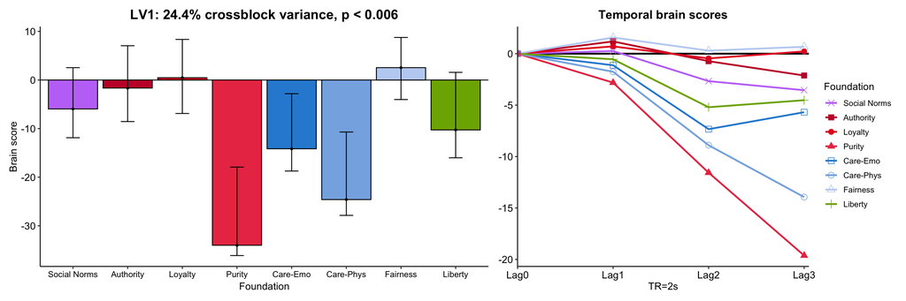

$~$

##### Cluster report highlights for LV1

[click here to see the full reports (I recommend right-clicking and opening in a new tab, as clicking directly will redirect you from this page).](https://docs.google.com/spreadsheets/d/1isl6kQoiA0U87170vrgqciAP5hAwQPr4AZ0v9jJAGKk/edit#gid=0)

| Clu. | Lag | BSR | Appro.P | Clu_Size.voxels. | Level.1 | Level.2 | Level.3 | Level.4 | Level.5 |
| --- | --- | --- | --- | --- | --- | --- | --- | --- | --- |
| 59 | 2 | -4.3995 | 0e+00 | 19 | Right Cerebellum | Anterior Lobe | Culmen | Gray Matter | * |
| 60 | 2 | -4.2489 | 0e+00 | 39 | Left Cerebrum | Limbic Lobe | Parahippocampal Gyrus | Gray Matter | Amygdala |
| 61 | 2 | -3.6917 | 2e-04 | 45 | Left Cerebrum | Temporal Lobe | Middle Temporal Gyrus | Gray Matter | Brodmann area 21 |
| 91 | 3 | -7.4806 | 0e+00 | 501 | Left Cerebrum | Frontal Lobe | Inferior Frontal Gyrus | Gray Matter | Brodmann area 46 |
| 92 | 3 | -7.3120 | 0e+00 | 235 | Left Cerebrum | Sub-lobar | Claustrum | Gray Matter | * |
| 93 | 3 | -5.4190 | 0e+00 | 73 | Left Cerebrum | Limbic Lobe | Parahippocampal Gyrus | Gray Matter | Amygdala |
| 94 | 3 | -5.2782 | 0e+00 | 145 | Right Cerebrum | Frontal Lobe | Inferior Frontal Gyrus | Gray Matter | Brodmann area 46 |
| 95 | 3 | -5.0713 | 0e+00 | 22 | Left Brainstem | Midbrain | * | Gray Matter | Mammillary Body |
| 96 | 3 | -4.9481 | 0e+00 | 127 | Left Cerebrum | Temporal Lobe | Middle Temporal Gyrus | Gray Matter | Brodmann area 21 |
| 97 | 3 | -4.7988 | 0e+00 | 133 | Left Cerebrum | Frontal Lobe | Inferior Frontal Gyrus | Gray Matter | Brodmann area 44 |
| 98 | 3 | -4.7951 | 0e+00 | 35 | Left Cerebrum | Limbic Lobe | Parahippocampal Gyrus | Gray Matter | Amygdala |
| 99 | 3 | -4.3233 | 0e+00 | 59 | Left Brainstem | Midbrain | * | Gray Matter | Red Nucleus |
| 100 | 3 | -4.2745 | 0e+00 | 10 | Left Cerebrum | Frontal Lobe | Inferior Frontal Gyrus | Gray Matter | Brodmann area 45 |
| 101 | 3 | -4.1582 | 0e+00 | 19 | Right Cerebrum | Limbic Lobe | Parahippocampal Gyrus | Gray Matter | Brodmann area 30 |
| 102 | 3 | -4.0849 | 0e+00 | 16 | Right Cerebrum | Sub-lobar | Thalamus | Gray Matter | * |
| 103 | 3 | -4.0702 | 0e+00 | 23 | Right Cerebrum | Limbic Lobe | Parahippocampal Gyrus | Gray Matter | Amygdala |

Combining the cluster reports with the LV pattern strongly suggests that this variable tracks something like an emotional empathetic response. Amygdala is engaged in 4 distinct subregions over the course of 2 lags. Inferior frontal gyrus, which seems to be a primary responder, has been anatomically double-dissociated with vmPFC in a lesion study comparing emotional empathy to cognitive empathy, respectively. [(source)](https://academic.oup.com/brain/article/132/3/617/336907)

$~$

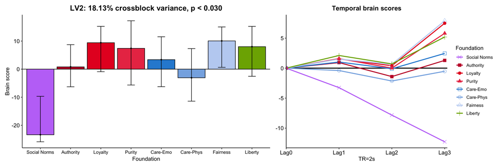

##### Cluster report highlights for LV2

[click here for LV2 cluster report (all of the cluster reports are on different sheets of the same google doc. I linked the specific sheets here for convenience.)](https://docs.google.com/spreadsheets/d/1isl6kQoiA0U87170vrgqciAP5hAwQPr4AZ0v9jJAGKk/edit#gid=331554496)

Clusters with positive BSR are associated with Fairness violations, and negative BSRs with Norm violations.

| Clu. | Lag | BSR | Appro.P | Clu_Size.voxels. | Level.1 | Level.2 | Level.3 | Level.4 | Level.5 |
| --- | --- | --- | --- | --- | --- | --- | --- | --- | --- |
| 13 | 2 | 6.7031 | 0e+00 | 679 | Left Cerebrum | Parietal Lobe | Precuneus | Gray Matter | Brodmann area 31 |
| 23 | 3 | 10.1125 | 0e+00 | 1684 | Left Cerebrum | Parietal Lobe | Precuneus | Gray Matter | Brodmann area 7 |
| 15 | 2 | 4.5541 | 0e+00 | 22 | Left Cerebrum | Limbic Lobe | Parahippocampal Gyrus | Gray Matter | Amygdala |
| 26 | 3 | 5.7047 | 0e+00 | 613 | Left Cerebrum | Parietal Lobe | Angular Gyrus | Gray Matter | Brodmann area 39 |
| 27 | 3 | 5.6470 | 0e+00 | 329 | Left Cerebrum | Frontal Lobe | Superior Frontal Gyrus | Gray Matter | Brodmann area 8 |
| 28 | 3 | 5.1875 | 0e+00 | 64 | Left Cerebrum | Frontal Lobe | Medial Frontal Gyrus | Gray Matter | Brodmann area 6 |
| 29 | 3 | 4.6828 | 0e+00 | 363 | Left Cerebrum | Frontal Lobe | Medial Frontal Gyrus | Gray Matter | Brodmann area 10 |
| 30 | 3 | 4.5614 | 0e+00 | 162 | Right Cerebrum | Temporal Lobe | Superior Temporal Gyrus | Gray Matter | Brodmann area 39 |
| 31 | 3 | 4.5383 | 0e+00 | 141 | Left Cerebrum | Frontal Lobe | Middle Frontal Gyrus | Gray Matter | Brodmann area 6 |
| 38 | 3 | 3.8336 | 1e-04 | 87 | Left Cerebrum | Sub-lobar | Caudate | Gray Matter | Caudate Head |
| 41 | 3 | -6.2063 | 0e+00 | 241 | Left Cerebrum | Parietal Lobe | Inferior Parietal Lobule | Gray Matter | Brodmann area 40 |
| 42 | 3 | -5.6736 | 0e+00 | 65 | Left Cerebrum | Sub-lobar | Insula | Gray Matter | Brodmann area 13 |
| 43 | 3 | -5.2777 | 0e+00 | 226 | Right Cerebrum | Temporal Lobe | Superior Temporal Gyrus | Gray Matter | Brodmann area 22 |
| 44 | 3 | -5.1926 | 0e+00 | 174 | Left Cerebrum | Temporal Lobe | Inferior Temporal Gyrus | Gray Matter | Brodmann area 37 |
| 45 | 3 | -4.9239 | 0e+00 | 352 | Left Cerebrum | Frontal Lobe | Paracentral Lobule | Gray Matter | Brodmann area 6 |
| 46 | 3 | -4.8127 | 0e+00 | 308 | Right Cerebrum | Parietal Lobe | Inferior Parietal Lobule | Gray Matter | Brodmann area 40 |
| 47 | 3 | -4.7436 | 0e+00 | 159 | Right Cerebrum | Frontal Lobe | Inferior Frontal Gyrus | Gray Matter | Brodmann area 46 |
| 48 | 3 | -4.6821 | 0e+00 | 152 | Left Cerebrum | Frontal Lobe | Inferior Frontal Gyrus | Gray Matter | Brodmann area 10 |
| 49 | 3 | -4.4457 | 0e+00 | 29 | Left Cerebrum | Temporal Lobe | Sub-Gyral | Gray Matter | Brodmann area 21 |
| 50 | 3 | -4.3205 | 0e+00 | 37 | Left Cerebrum | Frontal Lobe | Middle Frontal Gyrus | Gray Matter | Brodmann area 10 |
| 51 | 3 | -4.2856 | 0e+00 | 23 | Right Cerebrum | Limbic Lobe | Posterior Cingulate | Gray Matter | Brodmann area 30 |
| 52 | 3 | -4.2200 | 0e+00 | 31 | Right Cerebrum | Occipital Lobe | Cuneus | Gray Matter | Brodmann area 19 |
| 53 | 3 | -4.1903 | 0e+00 | 11 | Right Cerebrum | Frontal Lobe | Superior Frontal Gyrus | Gray Matter | Brodmann area 9 |
| 54 | 3 | -4.1171 | 0e+00 | 83 | Left Cerebrum | Occipital Lobe | Cuneus | Gray Matter | Brodmann area 19 |
| 58 | 3 | -3.8695 | 1e-04 | 32 | Left Cerebrum | Sub-lobar | Insula | Gray Matter | Brodmann area 13 |
| 61 | 3 | -3.4905 | 5e-04 | 11 | Right Cerebrum | Sub-lobar | Insula | Gray Matter | Brodmann area 13 |

### Model comparisons: moral judgment

This neural data suggests a new superordinate classification scheme: emotion, not emotion (we can think of a better name), fairness, and social norms. To assess whether this is useful for explaining behavior, I wanted to see how these new superordinate categories compare to the original superordinate categorization with respect to explaining variance in moral judgments. There is not a good way to statistically compare the 3 different models (one with just a global intercept and random effects for subjects and vignettes), so this is a qualitative comparison using standard metrics for evaluating mixed model performance.

```r
superordinateNull <- lmer(moral_decision ~ 1 + (1|subID) + (1|vigfile), data = data_old, control=lmerControl(optCtrl = list(maxeval=5000)))
superordinateOG <- lmer(moral_decision ~ superordinate + (1|subID) + (1|vigfile), data = data_old, control=lmerControl(optCtrl = list(maxeval=5000)))
superordinateNew <- lmer(moral_decision ~ superordinate_new + (1|subID) + (1|vigfile), data = data_old, control=lmerControl(optCtrl = list(maxeval=5000)))
kable(compare_performance(superordinateNull, superordinateOG, superordinateNew, bayesfactor = FALSE))
```

| Model | Type | AIC | BIC | R2_conditional | R2_marginal | ICC | RMSE |
| --- | --- | --- | --- | --- | --- | --- | --- |
| superordinateNull | lmerModLmerTest | 7506.270 | 7530.496 | 0.4751946 | 0.0000000 | 0.4751946 | 0.7239717 |
| superordinateOG | lmerModLmerTest | 7412.639 | 7455.034 | 0.4774696 | 0.2453677 | 0.3075696 | 0.7249011 |
| superordinateNew | lmerModLmerTest | 7385.091 | 7427.486 | 0.4766564 | 0.2805809 | 0.2725469 | 0.7253349 |

Interpretation: the neural superordinate categorization outperforms the original categorization on nearly every metric. Lower AIC & BIC = contains more information per number of parameters. R2_conditional = proportion of data explained by fixed & random effects, R2_marginal = proportion of data explained only by fixed effects (aka the one that matters here – New categories are better). ICC = amount of variance explained by random effects (lower = better fixed effects). RMSE = square root of error variance (lower = better model fit).

Now let’s see how the contrast values reported above change as a function of superordinate categorization. First, contrasts across the original superordinate structure (reproduced from above):

| contrast | estimate | SE | df | t.ratio | p.value |
| --- | --- | --- | --- | --- | --- |
| LibertyVsSocial | 1.4981577 | 0.1235891 | 111.8724 | 12.122083 | 0.000000 |
| BindingVsSocial | 1.2906747 | 0.1008918 | 111.7942 | 12.792665 | 0.000000 |
| IndividualizingVsSocial | 1.6239270 | 0.1008551 | 111.6329 | 16.101579 | 0.000000 |
| LibertyVsBinding | 0.2074830 | 0.1009817 | 112.1879 | 2.054659 | 0.253410 |
| LibertyVsIndividualizing | -0.1257693 | 0.1009483 | 112.0403 | -1.245878 | 1.000000 |
| IndividualizingVsBinding | 0.1866681 | 0.0713941 | 112.1245 | 2.614613 | 0.060963 |

And the new superordinate structure:

| contrast | estimate | SE | df | t.ratio | p.value |
| --- | --- | --- | --- | --- | --- |
| FairnessVsSocial | 1.6202652 | 0.1235544 | 111.7516 | 13.1137765 | 0.000000 |
| EmotionVsSocial | 1.7058935 | 0.1008726 | 111.7093 | 16.9113693 | 0.000000 |
| NotEmotionVsSocial | 1.1680057 | 0.1008791 | 111.7381 | 11.5782733 | 0.000000 |
| EmotionVsNotEmotion | 0.5378878 | 0.0713871 | 112.0803 | 7.5347995 | 0.000000 |
| EmotionVsFairness | 0.0856284 | 0.1009234 | 111.9358 | 0.8484496 | 1.000000 |
| NotEmotionVsFairness | -0.4522594 | 0.1009303 | 111.9663 | -4.4809100 | 0.000108 |

$~$

Finally, because LV1 is largely associated with emotional empathy areas, I wanted to see whether including information about participants’ emotions & trait-empathy levels improved our ability to model their moral judgments. I had to drop one participant for this analysis because of missing Qualtrics data, so the N=26 (but the model n=2870). We asked participants to report (1-7) the following emotional reactions to *each* vignette: anger, fear, sadness, disgust, contempt, amusement. For empathy, I am using 2 subscores from the Interpersonal Reactivity Index: personal distress (‘self-oriented’ feelings of anxiety or unease in tense interpersonal situations) and empathic concern (‘other-oriented’ feelings of concern). Below, we have a comparison among 4 types of models: one with no fixed effects (i.e., predicting moral judgment from subID and vignette file only), one with the foundations as a fixed effect, one with emotional reactions & empathy scores as fixed effects, and one with interactions between the foundations & both of the ‘em’ measures (empathy and emotion). All models have random intercepts for participant and vignette.

```r
# baseline: no fixed effects
modelNull <- lmer(moral_decision ~ 1 + (1|subID) + (1|vigfile), data = em_compare)

# standard: category as fixed effect
modelMoral <- lmer(moral_decision ~ category + (1|subID) + (1|vigfile), data = em_compare)

# just emotion & empathy as fixed effects
em_everything <- lmer(moral_decision ~ angry + sad + disgusted + afraid + contemptuous + amused +
                       PersonalDistressScore + EmpathicConcernScore +
                        (1|subID) + (1|vigfile), data=em_compare)

# each em (emotion & empathy) measure interacts with category
em_category <- lmer(moral_decision ~
                        category * angry +
                        category * amused +
                        category * sad +
                        category * afraid +
                        category * contemptuous +
                        category * disgusted +
                        category * PersonalDistressScore +
                        category * EmpathicConcernScore +
                        (1|subID) + (1|vigfile), data = em_compare)

kable(compare_performance(modelNull, modelMoral, em_everything, em_category, bayesfactor = FALSE, rank = TRUE))
```

| Model | Type | AIC | BIC | R2_conditional | R2_marginal | ICC | RMSE | Performance_Score |
| --- | --- | --- | --- | --- | --- | --- | --- | --- |
| em_category | lmerModLmerTest | 6606.480 | 7053.635 | 0.5460992 | 0.4361957 | 0.1949321 | 0.6694117 | 0.6591871 |
| em_everything | lmerModLmerTest | 6593.445 | 6664.989 | 0.4528987 | 0.1441087 | 0.3607819 | 0.6917474 | 0.5903396 |
| modelMoral | lmerModLmerTest | 6751.614 | 6817.197 | 0.4783960 | 0.3107855 | 0.2431906 | 0.7282512 | 0.3703213 |
| modelNull | lmerModLmerTest | 6883.905 | 6907.753 | 0.4754320 | 0.0000000 | 0.4754320 | 0.7260799 | 0.2756721 |

$~$

Performance score is the average of normalized values of each of these metrics, and is intended for quick, heuristic use, so we shouldn’t consider it the ultimate arbiter of model performance. However, all things considered, it does seem that em_category (interactions between foundations & em measures) is the best model for predicting moral judgments. Although it has a higher BIC than modelMoral, it compensates for that with a higher R2_marginal, lower ICC, and lower RMSE. We take this to suggest that, although moral foundations do a fine job explaining variance in moral judgments, including empathetic sensitivity & emotional reactions to moral transgressions paints a fuller picture (even when the stimuli are specifically designed to uniquely tap into each foundation!). See below a summary of the model & trends of each of the emotions.

$~$

*Note*: for this model, the coefficients are sum-coded/zero-centered. This means that the comparison class is the grand mean of approximately 0, rather than Social Norms. It also means that we don’t see Liberty in the model printout. But I’ve made some plots that help visualize the effect of each em measure on moral judgments in each foundation. The dotted line represents the main effect for that particular emotion, and any points/lines that do not touch the dotted line reflect significant effects.

$~$

|  | moral_decision |  |  |
| --- | --- | --- | --- |
| Predictors | Estimates | CI | p |
| Intercept | 2.41 | 2.30 – 2.53 | **<0.001** |
| Social Norms | -1.00 | -1.22 – -0.77 | **<0.001** |
| Authority | -0.08 | -0.22 – 0.05 | 0.239 |
| Loyalty | -0.10 | -0.24 – 0.03 | 0.139 |
| Purity | 0.00 | -0.17 – 0.18 | 0.955 |
| Care-Emo | 0.20 | 0.06 – 0.33 | **0.005** |
| Care-Phys | 0.51 | 0.38 – 0.65 | **<0.001** |
| Fairness | 0.36 | 0.22 – 0.50 | **<0.001** |
| Anger | 0.11 | 0.06 – 0.16 | **<0.001** |
| Amusement | -0.11 | -0.14 – -0.07 | **<0.001** |
| Sadness | 0.05 | 0.01 – 0.09 | **0.015** |
| Fear | -0.01 | -0.06 – 0.03 | 0.591 |
| Contempt | 0.08 | 0.03 – 0.13 | **0.001** |
| Disgust | 0.15 | 0.11 – 0.20 | **<0.001** |
| Personal Distress | 0.01 | -0.10 – 0.13 | 0.824 |
| Empathic Concern | -0.03 | -0.15 – 0.08 | 0.563 |
| Social Norms*Anger | -0.10 | -0.36 – 0.16 | 0.452 |
| Authority*Anger | 0.12 | 0.00 – 0.24 | **0.042** |
| Loyalty*Anger | -0.06 | -0.19 – 0.07 | 0.383 |
| Purity*Anger | -0.05 | -0.15 – 0.05 | 0.312 |
| Care-Emo*Anger | 0.05 | -0.06 – 0.16 | 0.367 |
| Care-Phys*Anger | -0.11 | -0.21 – -0.01 | **0.036** |
| Fairness*Anger | 0.03 | -0.07 – 0.13 | 0.520 |
| Social Norms*Amusement | 0.02 | -0.04 – 0.09 | 0.486 |
| Authority*Amusement | 0.05 | -0.04 – 0.14 | 0.273 |
| Loyalty*Amusement | 0.06 | -0.02 – 0.13 | 0.159 |
| Purity*Amusement | -0.03 | -0.10 – 0.05 | 0.466 |
| Care-Emo*Amusement | -0.05 | -0.14 – 0.05 | 0.328 |
| Care-Phys*Amusement | 0.14 | 0.06 – 0.22 | **0.001** |

[output cut: 52 more lines]

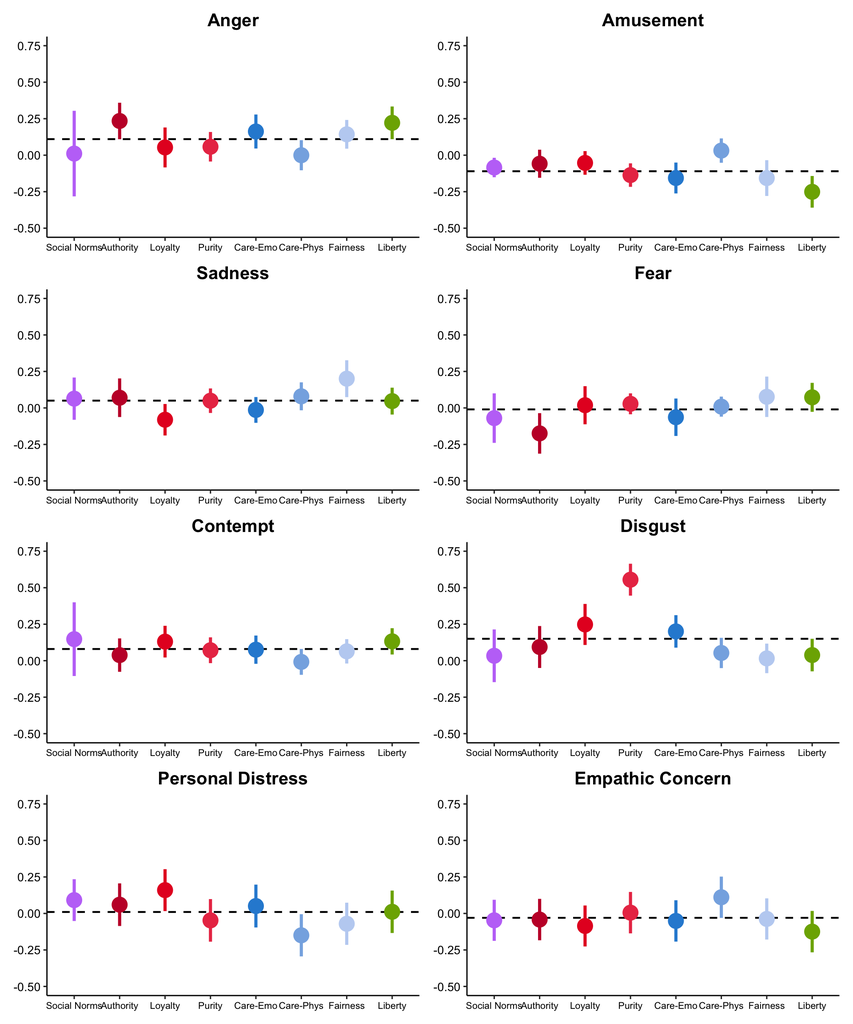

### Non-rotated task PLS

This is the theory-driven PLS analysis. I ran 2 of these. The first explicitly contrasted binding and individualizing foundations (dropping social norms, so that we could see how liberty behaves as its own superordinate category), and the second contrasted social norms against everything else. We will have to correct alpha for multiple comparisons (or else lump Liberty in with Social Norms), so neither of these came out as significant. (which is why I don’t have a link to the cluter report. Also, not sure why the color is funky for Care-Emo in the first plot)

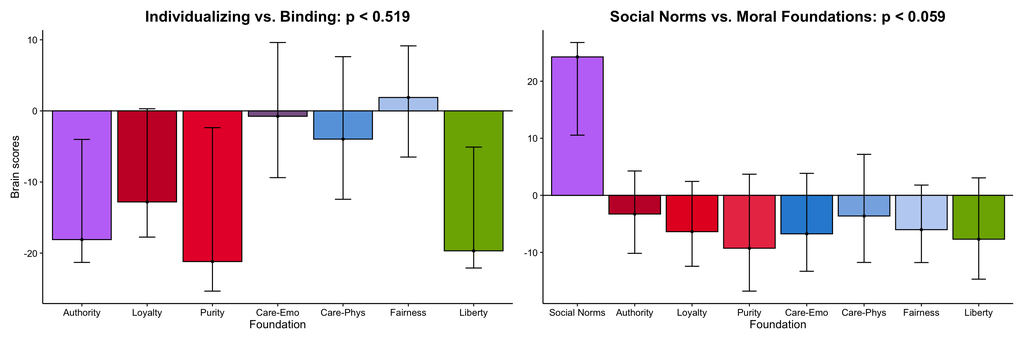

More evidence that the brain does not care about the individualizing/binding structure…

### And now for memory

#### Mixed model analyzing memory accuracy

*Note*: this and all following models are dummy-coded, like the very first model, so that Social Norms is the comparison category. This model additionally incorporates the ‘old’ level of ‘old/new’ into the comparison class (i.e., old[0] = New)

```r
# generalized linear mixed effect model because outcome is binary
modelMemory <- glmer(correct ~ category * old + (1 | subID),
                 data=data, family=binomial(link = 'logit'), control=glmerControl(optCtrl=list(maxfun=50000)))
tab_model(modelMemory)
```

|  | correct |  |  |
| --- | --- | --- | --- |
| Predictors | Odds Ratios | CI | p |
| (Intercept) | 4.60 | 3.31 – 6.39 | **<0.001** |
| category [Authority] | 0.65 | 0.46 – 0.91 | **0.013** |
| category [Loyalty] | 0.77 | 0.55 – 1.09 | 0.136 |
| category [Purity] | 1.26 | 0.87 – 1.82 | 0.222 |
| category [Care-Emo] | 1.02 | 0.71 – 1.45 | 0.928 |
| category [Care-Phys] | 0.81 | 0.57 – 1.15 | 0.236 |
| category [Fairness] | 0.91 | 0.64 – 1.29 | 0.589 |
| category [Liberty] | 0.81 | 0.57 – 1.15 | 0.240 |
| old [0] | 2.15 | 1.29 – 3.59 | **0.003** |
| category [Authority] * old [0] | 0.57 | 0.30 – 1.10 | 0.092 |
| category [Loyalty] * old [0] | 0.75 | 0.38 – 1.47 | 0.402 |
| category [Purity] * old [0] | 5.71 | 1.59 – 20.50 | **0.007** |
| category [Care-Emo] * old [0] | 1.22 | 0.58 – 2.59 | 0.596 |
| category [Care-Phys] * old [0] | 1.22 | 0.60 – 2.51 | 0.584 |
| category [Fairness] * old [0] | 1.69 | 0.78 – 3.66 | 0.185 |
| category [Liberty] * old [0] | 0.89 | 0.45 – 1.78 | 0.747 |
| Random Effects |  |  |  |
| σ<sup>2</sup> | 3.29 |  |  |
| τ<sub>00</sub> <sub>subID</sub> | 0.31 |  |  |
| ICC | 0.09 |  |  |
| N <sub>subID</sub> | 27 |  |  |
| Observations | 4937 |  |  |
| Marginal R<sup>2</sup> / Conditional R<sup>2</sup> | 0.110 / 0.187 |  |  |

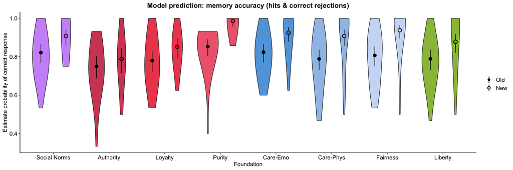

Traditional superordinate contrast

| old_pairwise | category_custom | estimate | SE | df | z.ratio | p.value |
| --- | --- | --- | --- | --- | --- | --- |
| 1 - 0 | LibertyVsSocial | 0.1134671 | 0.3513773 | Inf | 0.322921 | 0.7467551 |
| 1 - 0 | BindingVsSocial | -0.3003486 | 0.3429769 | Inf | -0.875711 | 0.3811872 |
| 1 - 0 | IndividualizingVsSocial | -0.3089599 | 0.3061219 | Inf | -1.009271 | 0.3128448 |
| 1 - 0 | LibertyVsBinding | 0.4138158 | 0.3243490 | Inf | 1.275835 | 0.2020139 |
| 1 - 0 | LibertyVsIndividualizing | 0.4224270 | 0.2851960 | Inf | 1.481181 | 0.1385582 |
| 1 - 0 | IndividualizingVsBinding | 0.3492292 | 0.2776560 | Inf | 1.257776 | 0.2084727 |

New superordinate contrast

| old_pairwise | category_custom | estimate | SE | df | z.ratio | p.value |
| --- | --- | --- | --- | --- | --- | --- |
| 1 - 0 | FairnessVsSocial | -0.5237155 | 0.3947391 | Inf | -1.3267384 | 0.1845952 |
| 1 - 0 | EmotionVsSocial | -0.7154039 | 0.3516105 | Inf | -2.0346490 | 0.0418862 |
| 1 - 0 | NotEmotionVsSocial | 0.3184896 | 0.2900359 | Inf | 1.0981040 | 0.2721591 |
| 1 - 0 | EmotionVsNotEmotion | -1.0338935 | 0.2680813 | Inf | -3.8566421 | 0.0001150 |
| 1 - 0 | EmotionVsFairness | -0.1916884 | 0.3788561 | Inf | -0.5059663 | 0.6128803 |
| 1 - 0 | NotEmotionVsFairness | 0.8422051 | 0.3226345 | Inf | 2.6103998 | 0.0090436 |

$~$

To more fully interrogate the utility of the new superordinate categories, we decided to do model comparisons for memory and confidence as well. If we find that this behavior is also better explained by the new superordinate structure, then we have stronger evidence arguing against the original structure. Likewise with the incorporation of emotion & empathy.

$~$

##### Comparing superordinate structures

```r
# baseline; fixed effect only for old/new status
modelMemoryNull <- glmer(correct ~ old + (1 | subID) + (1|vigfile),
                 data=data, family=binomial(link = 'logit'), control=glmerControl(optCtrl=list(maxfun=50000)))

# same model as above, interaction between foundation & old/new status
modelMemory <- glmer(correct ~ category * old + (1|subID) + (1|vigfile),
                     data=data, family = binomial(link = 'logit'), control=glmerControl(optCtrl = list(maxfun=5000)))

# interaction between original superordinate categories & old/new
modelSupMemory <- glmer(correct ~ superordinate * old + (1 | subID) + (1|vigfile),
                 data=data, family=binomial(link = 'logit'), control=glmerControl(optCtrl=list(maxfun=50000)))

# interaction between new superordinate categories & old/new
modelSupMemoryNew <- glmer(correct ~ superordinate_new * old + (1 | subID) + (1|vigfile),
                 data=data, family=binomial(link = 'logit'), control=glmerControl(optCtrl=list(maxfun=50000)))

kable(compare_performance(modelMemoryNull, modelSupMemory, modelSupMemoryNew, modelMemory, bayesfactor = FALSE, rank = TRUE))
```

| Model | Type | AIC | BIC | R2_conditional | R2_marginal | ICC | RMSE | LOGLOSS | SCORE_LOG | Performance_Score |
| --- | --- | --- | --- | --- | --- | --- | --- | --- | --- | --- |
| modelMemoryNull | glmerMod | 4024.977 | 4050.995 | 0.3577566 | 0.0362243 | 0.3336173 | 0.8457491 | 0.3576458 | -Inf | 0.5715138 |
| modelMemory | glmerMod | 4028.088 | 4145.170 | 0.3790523 | 0.0979765 | 0.3116058 | 0.8457642 | 0.3576585 | -Inf | 0.5288666 |
| modelSupMemoryNew | glmerMod | 4025.312 | 4090.357 | 0.3608635 | 0.0589897 | 0.3207976 | 0.8459492 | 0.3578150 | -Inf | 0.4975210 |
| modelSupMemory | glmerMod | 4035.420 | 4100.465 | 0.3577439 | 0.0393772 | 0.3314169 | 0.8458207 | 0.3577063 | -Inf | 0.3465373 |

$~$

Interpretation: using actual categories is better for predicting memory than either of the superordinate categorizations (higher R2_marginal), but the neurally derived superordinate categories are indeed better at predicting successful memory than the traditional superordinate categories (lower AIC & BIC, higher R_ marginal, lower ICC).

$~$

##### Comparing inclusion of empathy & emotion

For these memory models, we will only be evaluating memory performance for vignettes viewed in the scanner and again will have N=26 but model n > 2500. This is because we did not collect emotion ratings for the lure vignettes presented during the memory test, and we had incomplete data for one participant’s qualtrics responses.

```r
em_compare$correct <- as.factor(em_compare$correct)

# baseline
modelMemoryNull <- glmer(correct ~ 1 + (1 | subID) + (1|vigfile),
                 data=em_compare, family=binomial(link = 'logit'), control=glmerControl(optCtrl=list(maxfun=50000)))

# fixed effect only for coundations
modelMemory <- glmer(correct ~ category + (1|subID) + (1|vigfile),
                     data=em_compare, family = binomial(link = 'logit'), control=glmerControl(optCtrl = list(maxfun=5000)))

# fixed effects only for emotion & empathy
em_memory <- glmer(correct ~ angry + sad + disgusted + afraid + contemptuous + amused +
                       PersonalDistressScore + EmpathicConcernScore +
                       (1|subID) + (1|vigfile),
                       data=em_compare, family = binomial(link = 'logit'), control=glmerControl(optCtrl = list(maxfun=5000)))

# interaction between em measures & foundations
em_category_memory <- glmer(correct ~
                                 category * angry +
                                 category * amused +
                                 category * sad +
                                 category * afraid +
                                 category * contemptuous +
                                 category * disgusted +
                                 category * PersonalDistressScore +
                                 category * EmpathicConcernScore +
                                 (1 | subID) + (1|vigfile),
                 data=em_compare, family=binomial(link = 'logit'), control=glmerControl(optCtrl=list(maxfun=1e9),
                                                                                        optimizer = 'bobyqa'))

kable(compare_performance(modelMemoryNull, modelMemory, em_memory, em_category_memory, bayesfactor = FALSE, rank = TRUE))
```

| Model | Type | AIC | BIC | R2_conditional | R2_marginal | ICC | RMSE | LOGLOSS | SCORE_LOG | SCORE_SPHERICAL | Performance_Score |
| --- | --- | --- | --- | --- | --- | --- | --- | --- | --- | --- | --- |
| modelMemoryNull | glmerMod | 2241.001 | 2258.888 | 0.4059242 | 0.0000000 | 0.4059242 | 0.8125999 | 0.3301593 | -Inf | NA | 0.5340739 |
| modelMemory | glmerMod | 2245.568 | 2305.188 | 0.4149256 | 0.0351617 | 0.3936036 | 0.8121777 | 0.3298163 | -Inf | NA | 0.4793151 |
| em_memory | glmerMod | 2226.150 | 2291.733 | 0.4102916 | 0.0375863 | 0.3872610 | 0.8089391 | 0.3271913 | -Inf | 0.0003484 | 0.4750050 |
| em_category_memory | glmerMod | 2282.947 | 2724.140 | 0.4636215 | 0.1168158 | 0.3926765 | 0.7944212 | 0.3155525 | -Inf | 0.0003484 | 0.4700245 |

$~$

Interpretation: this is effectively a null result. Although em_category_memory has the best R2_marginal, its AIC and BIC are much higher than modelMemory and em_memory. All 3 of those models are likewise tied on RMSE and ICC, both of which are not very good. It is important to keep in mind that we were not able to include an effect of old/new in these models, which does have a main effect and interacts with foundations, because of the study design.

$~$

### And finally, confidence

Again, this is a dummy-coded model. Same intercepts as the last, with an additional ‘Correct’ for ‘Correct/Incorrect’.

|  | confresp |  |  |
| --- | --- | --- | --- |
| Predictors | Estimates | CI | p |
| (Intercept) | 2.71 | 2.58 – 2.84 | **<0.001** |
| category [Authority] | -0.16 | -0.31 – -0.02 | **0.027** |
| category [Loyalty] | -0.26 | -0.40 – -0.12 | **<0.001** |
| category [Purity] | 0.05 | -0.09 – 0.20 | 0.451 |
| category [Care-Emo] | -0.05 | -0.19 – 0.10 | 0.522 |
| category [Care-Phys] | -0.11 | -0.26 – 0.03 | 0.118 |
| category [Fairness] | -0.05 | -0.19 – 0.10 | 0.525 |
| category [Liberty] | 0.03 | -0.11 – 0.18 | 0.648 |
| old [0] | -0.32 | -0.49 – -0.16 | **<0.001** |
| correct [0] | -0.57 | -0.72 – -0.41 | **<0.001** |
| category [Authority] * old [0] | -0.11 | -0.35 – 0.13 | 0.360 |
| category [Loyalty] * old [0] | 0.17 | -0.07 – 0.41 | 0.170 |
| category [Purity] * old [0] | 0.13 | -0.11 – 0.37 | 0.283 |
| category [Care-Emo] * old [0] | -0.13 | -0.37 – 0.11 | 0.284 |
| category [Care-Phys] * old [0] | -0.01 | -0.24 – 0.23 | 0.947 |
| category [Fairness] * old [0] | 0.02 | -0.22 – 0.25 | 0.883 |
| category [Liberty] * old [0] | -0.05 | -0.29 – 0.18 | 0.658 |
| category [Authority] * correct [0] | 0.01 | -0.20 – 0.22 | 0.925 |
| category [Loyalty] * correct [0] | 0.04 | -0.17 – 0.24 | 0.734 |
| category [Purity] * correct [0] | 0.10 | -0.13 – 0.34 | 0.396 |
| category [Care-Emo] * correct [0] | -0.15 | -0.37 – 0.07 | 0.171 |
| category [Care-Phys] * correct [0] | 0.02 | -0.19 – 0.23 | 0.876 |
| category [Fairness] * correct [0] | 0.00 | -0.21 – 0.22 | 0.994 |
| category [Liberty] * correct [0] | -0.07 | -0.29 – 0.14 | 0.505 |
| old [0] * correct [0] | -0.27 | -0.58 – 0.04 | 0.087 |
| (category [Authority] *old [0])* correct [0] | 0.66 | 0.26 – 1.06 | **0.001** |
| (category [Loyalty] * old [0]) * correct [0] | 0.32 | -0.11 – 0.76 | 0.141 |
| (category [Purity] * old [0]) * correct [0] | -0.64 | -1.41 – 0.13 | 0.104 |
| (category [Care-Emo] *old [0])* correct [0] | 0.31 | -0.14 – 0.77 | 0.177 |
| (category [Care-Phys] *old [0])* correct [0] | 0.02 | -0.41 – 0.45 | 0.928 |
| (category [Fairness] *old [0])* correct [0] | 0.15 | -0.32 – 0.62 | 0.534 |
| (category [Liberty] * old [0]) * correct [0] | 0.26 | -0.16 – 0.68 | 0.233 |
| Random Effects |  |  |  |
| σ<sup>2</sup> | 0.36 |  |  |
| τ<sub>00</sub> <sub>vigfile</sub> | 0.02 |  |  |
| τ<sub>00</sub> <sub>subID</sub> | 0.05 |  |  |
| ICC | 0.17 |  |  |
| N <sub>subID</sub> | 27 |  |  |
| N <sub>vigfile</sub> | 183 |  |  |
| Observations | 4937 |  |  |
| Marginal R<sup>2</sup> / Conditional R<sup>2</sup> | 0.156 / 0.304 |  |  |

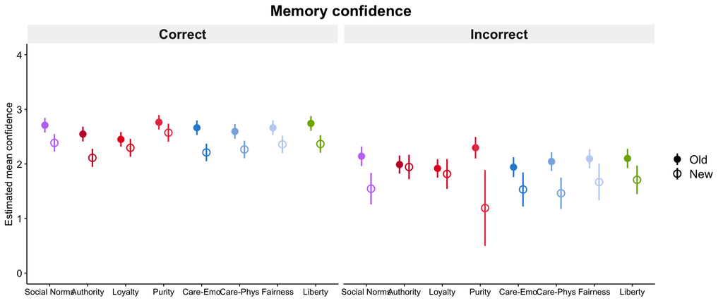

Old superordinate structure

| old_pairwise | correct_pairwise | category_custom | estimate | SE | df | t.ratio | p.value |
| --- | --- | --- | --- | --- | --- | --- | --- |
| 1 - 0 | 1 - 0 | LibertyVsSocial | 0.2561124 | 0.2146917 | 4866.016 | 1.1929310 | 0.2329546 |
| 1 - 0 | 1 - 0 | BindingVsSocial | 0.1146241 | 0.2097175 | 4869.727 | 0.5465641 | 0.5847032 |
| 1 - 0 | 1 - 0 | IndividualizingVsSocial | 0.1610616 | 0.1859822 | 4880.048 | 0.8660052 | 0.3865299 |
| 1 - 0 | 1 - 0 | LibertyVsBinding | 0.1414884 | 0.1997649 | 4821.211 | 0.7082744 | 0.4788091 |
| 1 - 0 | 1 - 0 | LibertyVsIndividualizing | 0.0950508 | 0.1745805 | 4856.223 | 0.5444528 | 0.5861549 |
| 1 - 0 | 1 - 0 | IndividualizingVsBinding | 0.1428222 | 0.1702305 | 4869.464 | 0.8389930 | 0.4015144 |

New superordinate structure

| old_pairwise | correct_pairwise | category_custom | estimate | SE | df | t.ratio | p.value |
| --- | --- | --- | --- | --- | --- | --- | --- |
| 1 - 0 | 1 - 0 | FairnessVsSocial | 0.1489152 | 0.2397981 | 4878.461 | 0.6210024 | 0.5346271 |
| 1 - 0 | 1 - 0 | EmotionVsSocial | -0.1024609 | 0.2131229 | 4873.885 | -0.4807599 | 0.6307088 |
| 1 - 0 | 1 - 0 | NotEmotionVsSocial | 0.4138790 | 0.1784182 | 4815.733 | 2.3197123 | 0.0203981 |
| 1 - 0 | 1 - 0 | EmotionVsNotEmotion | -0.5163399 | 0.1644927 | 4852.771 | -3.1389829 | 0.0017055 |
| 1 - 0 | 1 - 0 | EmotionVsFairness | -0.2513761 | 0.2297524 | 4866.480 | -1.0941174 | 0.2739576 |
| 1 - 0 | 1 - 0 | NotEmotionVsFairness | 0.2649638 | 0.1978718 | 4862.003 | 1.3390677 | 0.1806112 |

The new superordinate categories give us a more meaningful structure to the foundations.

#### Confidence superordinate model comparisons

```r
modelConfidenceNull <- lmer(confresp ~  old * correct + (1 | subID) + (1|vigfile), data=data,
                        control=lmerControl(optCtrl = list(maxeval=5000)))

modelConfidenceSup <- lmer(confresp ~ superordinate * old * correct + (1 | subID) + (1|vigfile), data=data,
                        control=lmerControl(optCtrl = list(maxeval=5000)))

modelConfidenceSupNew <- lmer(confresp ~ superordinate_new * old * correct + (1 | subID) + (1|vigfile), data=data,
                        control=lmerControl(optCtrl = list(maxeval=5000)))

kable(compare_performance(modelConfidenceNull, modelConfidenceSup, modelConfidenceSupNew, modelConfidence, bayesfactor = FALSE, rank = TRUE))
```

| Model | Type | AIC | BIC | R2_conditional | R2_marginal | ICC | RMSE | Performance_Score |
| --- | --- | --- | --- | --- | --- | --- | --- | --- |
| modelConfidenceSup | lmerModLmerTest | 9295.112 | 9418.698 | 0.2972411 | 0.1318083 | 0.1905488 | 0.5863438 | 0.5227183 |
| modelConfidenceSupNew | lmerModLmerTest | 9294.229 | 9417.814 | 0.2979656 | 0.1335965 | 0.1897143 | 0.5865673 | 0.5121144 |
| modelConfidenceNull | lmerModLmerTest | 9255.599 | 9301.130 | 0.2943196 | 0.1273252 | 0.1913593 | 0.5874917 | 0.5000000 |
| modelConfidence | lmerModLmerTest | 9312.866 | 9540.524 | 0.3035070 | 0.1560666 | 0.1747061 | 0.5862049 | 0.5000000 |

But, they don’t seem to have much of an advantage when explaining memory confidence. The old and new superordinate categories are effectively tied on all of our measures, with a marginally lower AIC and BIC.

#### Confidence empathy & emotion model comparisons

Again, here we are working with a subset of the data: only old vignettes, and dropping one participant. So we only have 1 new fixed effect that’s included in every model: whether the vignette was successfully remembered.

```r
# baseline
modelConfidenceNull <- lmer(confresp ~  correct + (1 | subID) + (1|vigfile),
                            data=em_compare, control=lmerControl(optCtrl = list(maxeval=5000)))

# fixed effect for foundations & correct
modelConfidence <- lmer(confresp ~ category * correct + (1 | subID) + (1|vigfile),
                        data=em_compare, control=lmerControl(optCtrl = list(maxeval=5000)))

# fixed effects for emotion & empathy interacting with correct
em_confidence <- lmer(confresp ~
                        correct * angry +
                        correct * sad +
                        correct * disgusted +
                        correct * afraid +
                        correct * contemptuous +
                        correct * amused +
                        correct * PersonalDistressScore +
                        correct * EmpathicConcernScore +
                        (1|subID) + (1|vigfile),
                        data=em_compare, control=lmerControl(optCtrl = list(maxeval=5000)))

# fixed effects for correct, foundation, and em measure interaction
em_category_confidence <- lmer(confresp ~
                                 correct * category * angry +
                                 correct * category * amused +
                                 correct * category * sad +
                                 correct * category * afraid +
                                 correct * category * contemptuous +
                                 correct * category * disgusted +
                                 correct * category * PersonalDistressScore +
                                 correct * category * EmpathicConcernScore +
                                 (1 | subID) + (1|vigfile),
                 data=em_compare, control=lmerControl(optCtrl=list(maxfun=5000)))

kable(compare_performance(modelConfidenceNull, modelConfidence, em_confidence, em_category_confidence, bayesfactor = FALSE, rank = TRUE))
```

| Model | Type | AIC | BIC | R2_conditional | R2_marginal | ICC | RMSE | Performance_Score |
| --- | --- | --- | --- | --- | --- | --- | --- | --- |
| em_category_confidence | lmerModLmerTest | 5449.674 | 6326.098 | 0.3147739 | 0.1859479 | 0.1582527 | 0.5128524 | 0.5832937 |
| em_confidence | lmerModLmerTest | 4946.438 | 5071.641 | 0.2726533 | 0.1262537 | 0.1675539 | 0.5267868 | 0.5176831 |
| modelConfidenceNull | lmerModLmerTest | 4848.953 | 4878.763 | 0.2650413 | 0.1164943 | 0.1681336 | 0.5290066 | 0.5000000 |
| modelConfidence | lmerModLmerTest | 4881.603 | 4994.882 | 0.2772067 | 0.1512712 | 0.1483813 | 0.5281414 | 0.4440519 |

Here we see that including emotion & empathy information does slightly improve our ability to explain/predict memory confidence, though the difference in BIC is substantial relative to the improvement in R2_marginal and RMSE.

$~$

### Concluding thoughts / idea on paper narrative

$~$

This narrative is tenative and conditional on your reactions to these data. I will start the methods & results section of the paper tomorrow, and share with all of you a Google Doc of the full manuscript, much of which will be adapted from what Ellie has already written. Please let me know any thoughts you may have, and do not hestiate to be in touch if you’d like to chat about anything!